# Batting analysis

Jerome Vonk

March 2nd, 2018

## The data

Sean Lahman’s Baseball Database contains pitching, hitting, and fielding statistics for Major League Baseball from 1871 through 2016. It includes data from the two current leagues (American and National), the four other “major” leagues (American Association, Union Association, Players League, and Federal League), and the National Association of 1871-1875.

This database was created by Sean Lahman, who pioneered the effort to make baseball statistics freely available to the general public. What started as a one man effort in 1994 has grown tremendously, and now a team of researchers have collected their efforts to make this the largest and most accurate source for baseball statistics available anywhere.

For this analysis, we’re using the following libraries: *Lahman*, *dplyr* and *ggplot2*

Let’s have a look at the Batting table:

```
##    playerID yearID stint teamID lgID  G  AB  R  H X2B X3B HR RBI SB CS BB
## 1 abercda01   1871     1    TRO   NA  1   4  0  0   0   0  0   0  0  0  0
## 2  addybo01   1871     1    RC1   NA 25 118 30 32   6   0  0  13  8  1  4
## 3 allisar01   1871     1    CL1   NA 29 137 28 40   4   5  0  19  3  1  2
## 4 allisdo01   1871     1    WS3   NA 27 133 28 44  10   2  2  27  1  1  0
## 5 ansonca01   1871     1    RC1   NA 25 120 29 39  11   3  0  16  6  2  2
## 6 armstbo01   1871     1    FW1   NA 12  49  9 11   2   1  0   5  0  1  0
##   SO IBB HBP SH SF GIDP
## 1  0  NA  NA NA NA   NA
## 2  0  NA  NA NA NA   NA
## 3  5  NA  NA NA NA   NA
## 4  2  NA  NA NA NA   NA
## 5  1  NA  NA NA NA   NA
## 6  1  NA  NA NA NA   NA
```

Now, let’s group by userID:

```r
groups  <- group_by(Batting, playerID)
grouped <- summarise(groups,
                     games = sum(G),
                     homeruns = sum(HR),
                     strikeouts = sum(SO))


grouped <- arrange(grouped, desc(games))
```

This is what we get:

```
## # A tibble: 6 x 4
##   playerID  games homeruns strikeouts
##   <chr>     <int>    <int>      <int>
## 1 rosepe01   3562      160       1143
## 2 yastrca01  3308      452       1393
## 3 aaronha01  3298      755       1383
## 4 henderi01  3081      297       1694
## 5 cobbty01   3035      117         NA
## 6 murraed02  3026      504       1516
```

## Plot 1: games played versus homeruns

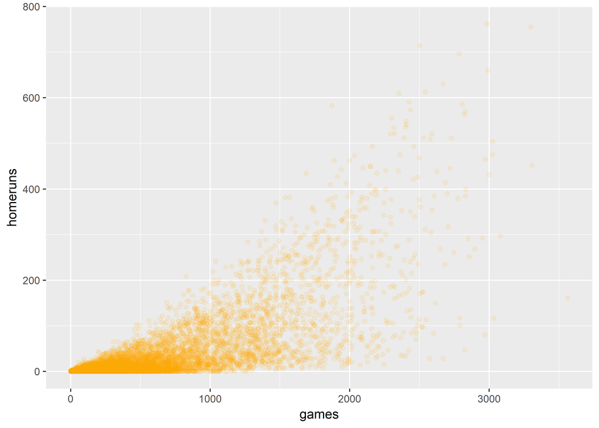

```r
ggplot(aes(x = games, y = homeruns), data = grouped) +
  geom_point(alpha = 0.1, color = 'orange')
```

and the correlation is

```r
with(grouped, cor.test(games, homeruns))
```

```
##
##  Pearson's product-moment correlation
##
## data:  games and homeruns
## t = 161.94, df = 18913, p-value < 2.2e-16
## alternative hypothesis: true correlation is not equal to 0
## 95 percent confidence interval:
##  0.7561909 0.7681351
## sample estimates:
##       cor
## 0.7622279
```

It seems very logical that the more games played, the more likely it is to have more homeruns, right? The plot and the value of the Pearson correlation indicate that.

## Plot 2 : games played versus strikeouts

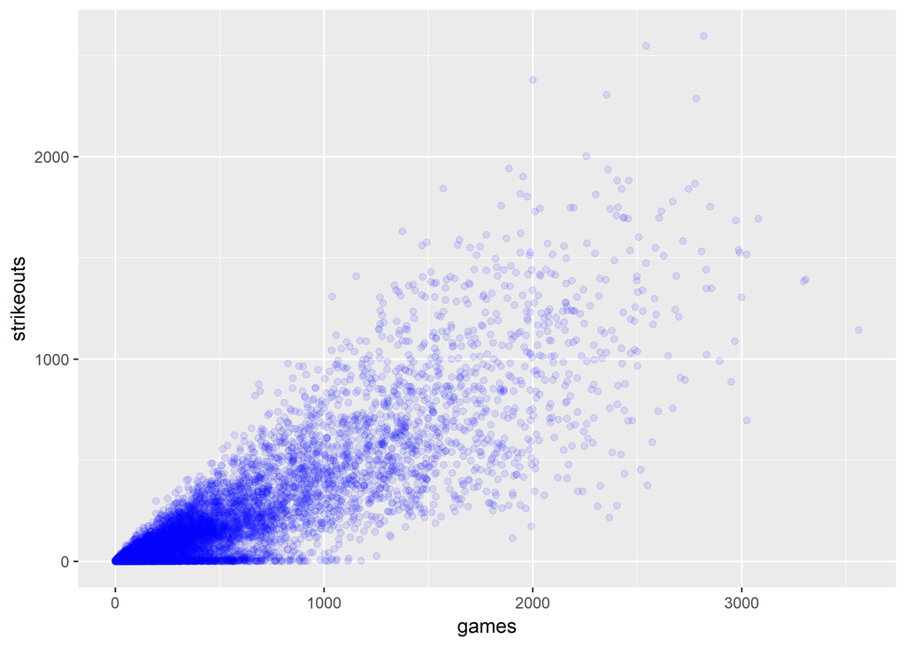

```r
ggplot(aes(x = games, y = strikeouts), data = grouped) +
  geom_point(alpha = 0.1, color = 'blue')
```

and the correlation is

```r
with(grouped, cor.test(games, strikeouts))
```

```
##
##  Pearson's product-moment correlation
##
## data:  games and strikeouts
## t = 236, df = 16181, p-value < 2.2e-16
## alternative hypothesis: true correlation is not equal to 0
## 95 percent confidence interval:
##  0.8767523 0.8836907
## sample estimates:
##       cor
## 0.8802685
```

Games played and strikeouts looks even more correlated!

## Plot 3 : homeruns versus strikeouts

What will we find about homeruns and strikeouts? Are they correlated?

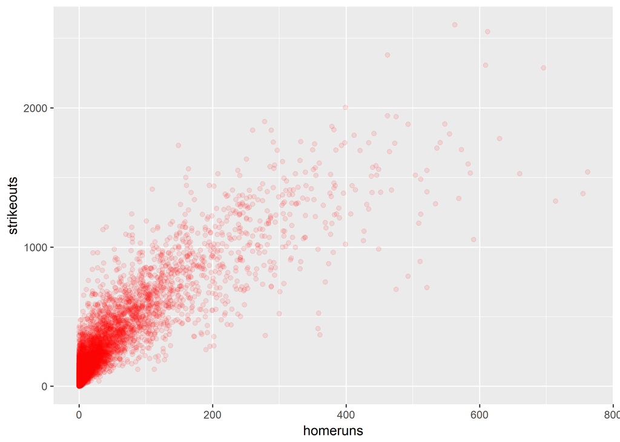

```r
ggplot(aes(x = homeruns, y = strikeouts), data = grouped) +
  geom_point(alpha = 0.1, color = 'red')
```

and the correlation is

```r
with(grouped, cor.test(homeruns, strikeouts))
```

```
##
##  Pearson's product-moment correlation
##
## data:  homeruns and strikeouts
## t = 245.59, df = 16181, p-value < 2.2e-16
## alternative hypothesis: true correlation is not equal to 0
## 95 percent confidence interval:
##  0.8846517 0.8911713
## sample estimates:
##       cor
## 0.8879561
```

That’s way more than I expected. Could it simply because more homeruns means more games played, and that would lead eventually to more strikeouts as well. So let’s try something else

## Plot 4 : home runs per game versus strikeouts per game

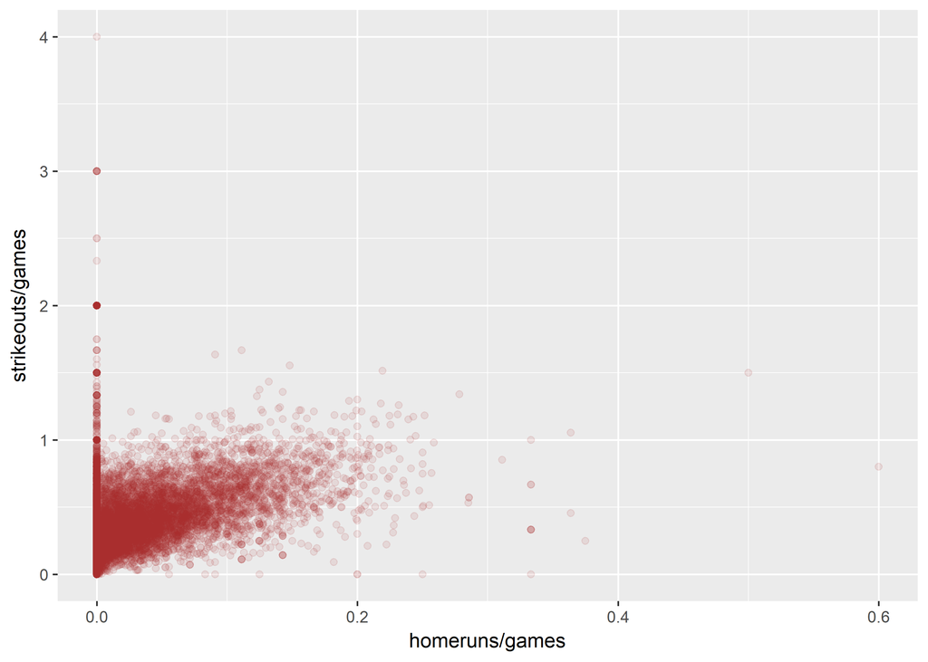

```r
ggplot(aes(x = homeruns/games, y = strikeouts/games), data = grouped) +
  geom_point(alpha = 0.1, color = 'brown')
```

and the correlation is

```r
with(grouped, cor.test(homeruns/games, strikeouts/games))
```

```
##
##  Pearson's product-moment correlation
##
## data:  homeruns/games and strikeouts/games
## t = 61.135, df = 16181, p-value < 2.2e-16
## alternative hypothesis: true correlation is not equal to 0
## 95 percent confidence interval:
##  0.4205745 0.4456080
## sample estimates:
##       cor
## 0.4331748
```

Comment: Now it makes more sense for me. The Perason correlation value dropped a lot. Looks like the number of homeruns and strikeouts is not strongly correlated anymore.